[figure not shown]

HFES 2026

State Emergency Operations Center

# An Integrated Multimodal Framework for Measuring Physical Team Processes During State Emergency Operations Center Activations

**Spenceley, R.**<sup>1,2</sup>, Yadav, A.<sup>1</sup>, & Mehta, R.<sup>1</sup>

<sup>1</sup> NeuroErgonomics Laboratory, University of Wisconsin–Madison  
<sup>2</sup> INTEGRATE: An NSF Research Traineeship

[figure not shown]

[figure not shown]

Disclosure

## AI disclosure

Claude was used to assist in the **visual design** of this slide deck.

Background

## Large-scale emergency response

First responders

firefighters, EMS, police on scene

Dispatch

routes calls and resources

State officials

coordinate across agencies

Scale and coordination demands increase →

Emergency Operations Center (EOC)

“A centralized physical or virtual location where government agencies, organizations, and key decision makers gather to coordinate overall disaster response and recovery.”

FEMA, 2022

Background

## Intro to an EOC

01**Two levels**

EOCs exist at both the county and state (sEOC) levels.

02**Few, if any, employees**

EOCs ‘borrow’ employees from other agencies when activated.

03**Ad hoc teams**

Employees represent their ‘home’ agency and form teams that may have never worked together before.

04**Activation depends on local regulations**

Can include emergencies that exceed “normal resources” or need multiple agencies, emergency declarations, and ongoing hazards.

Background

## EOC activation

1

Emergency occurs

2

First responders respond

3

County EOC monitors / activates if needed

4

State EOC monitors / activates if needed

sEOC

DOT

NWS

Fire / EMS

Police

Recruits members from agencies, who then come to the sEOC

Background

## EOC organization

Despite representing different agencies, EOC members can be **clustered into groups by responsibility**.

Groupings are specific to a given EOC.

Members from many agencies

Managers

Resource support

Situational awareness

Planning support

Center support

Gap

## Existing measures to study an EOC

**Generic teamwork features**

Based on general teamwork (e.g., TeamSTEPPS) rather than context-dependent, interorganizational features.

Taylor, 2011; Morian et al., 2023

**Observational research is equally limited**

- Requires multiple researchers, often rotating
- After-action reviews
- Observer-rated behavioral checklists

**EOC-generated materials**

Provide little insight into the how or why.

Gap

## Existing methodologies emphasize qualitative and subjective data

Useful to capture preferences, but missing a **team science** perspective. Neal, 2003

In large teams

**SMM**Shared mental models

**SA**Situation awareness

**TC**Team cognition

**TMS**Transactive memory systems

↓ Strong empirical links to team **performance**, **coordination**, and **adaptability** Mathieu et al., 2000

Insufficient shared understanding can show up as

Communication inefficienciesUneven participationDelayed coordination

Mathieu et al., 2000

In an EOC, SMMs may

Facilitate interagency coordinationBuild effective TMSCreate resilient teams

Kapucu, 2006; Cooke et al., 2000

Thus, there is a need to study the **underlying mechanisms** of large-scale teams in an EOC.

Aims

## Aims and objectives

Build on existing methodologies by combining **subjective** and **objective measurements** to quantify situation awareness, mental models, and coordination.

**Subjective**

Post-exercise survey of workers’ beliefs and preferences

**Video**

Spatial positioningMotion entropy

**Audio**

Features of speech

Method

## Approach

Observational study at a **midwestern sEOC** during an annual drill.

~5 h

drill duration

65

individuals participated

6

controllers injected information

Data collected

**Video**

**Audio**

**Subjective**

Method

## The sEOC

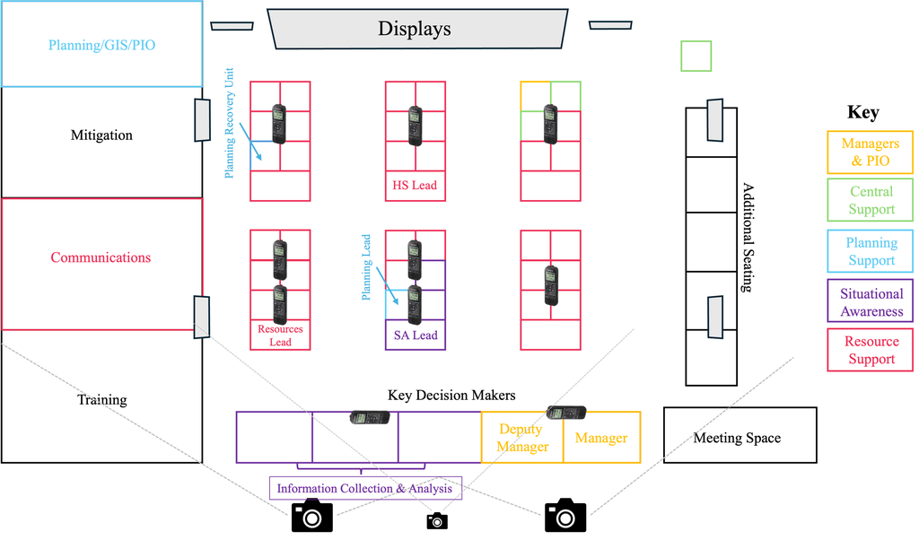

3

**GoPro cameras**

- 1080p, ~90% of the sEOC
- Left and right on 400 cm tripods; middle on 130 cm tripod
- Continuous recording, saved in hour-long segments

10

**Sony voice recorders**

- Placed around the room
- 2 at tables where high communication was expected

Method · Video pipeline

## Video analysis

1

YOLOv8m-face + Gaussian blur

**De-identify**

Faces detected and blurred

→

2

Ultralytics YOLOv5x

**Detect people**

Bounding boxes around each person in every video frame

→

3

DeepSORT

**Track**

Multi-object tracking with local IDs; handles brief occlusions

→

4

Custom layer on DeepSORT

**Re-identify**

Gallery of up to 100 appearance-based features that “new” IDs are compared to

- Spatial continuity as a fallback
- Custom Python script to examine trajectory continuity

Method · Video pipeline

## Output

[video not shown]

**Not perfect**

Some IDs do disappear

However, this pipeline is able to **re-identify dropped IDs**

Method · Audio pipeline

## Audio data

1

DeepFilterNet2

**Denoise**

Attenuate background noise

→

2

OpenAI Whisper

**Transcribe**

Speech to text

→

3

pyannote.audio 3.1

**Diarize**

Who spoke when

→

4

Custom

**Compute metrics**

Additional speech features

- Speaking time, turn count, turn rate
- Dominance
- Graph-based measures

Method · Survey

## Subjective data

17

survey responses

Custom post-exercise survey, based on an existing questionnaire provided by EOC staff

Scale

1

2

3

4

5

Strongly disagreeStrongly agree

**Physical movement**When I needed to discuss something immediately with someone, I moved over to their workstation and talked with them

**Awareness of responsibilities**I had a strong understanding of my responsibilitiesWhile in the drill, I knew who I should report toI knew how to prioritize my responsibilities while participating in the drill

**Situation awareness**I was aware of what other teams were working onI understood what other teams required of meI received situational awareness information in a timely mannerI didn’t need to ask people about what was happening in the drill

**Workstation preferences**I did not have enough desk space to effectively perform my dutiesMy workstation was still comfortable by the end of the drillI would have found an additional monitor useful at my workstation

Results · Survey (n = 17)

## Subjective results

[figure not shown]

**Situation awareness is the gap**Low awareness of other teams’ tasks (*M* = 2.41)

**Movement drives coordination**Workers walk over rather than rely on seating (*M* = 4.65)

**No one-size-fits-all workstation**Responses vary widely by workstation

**Procedures need monitoring**Room to track familiarity with responsibilities

Cross-team situation awareness, not workstation comfort, as the main design target

Results · Video

## Video results

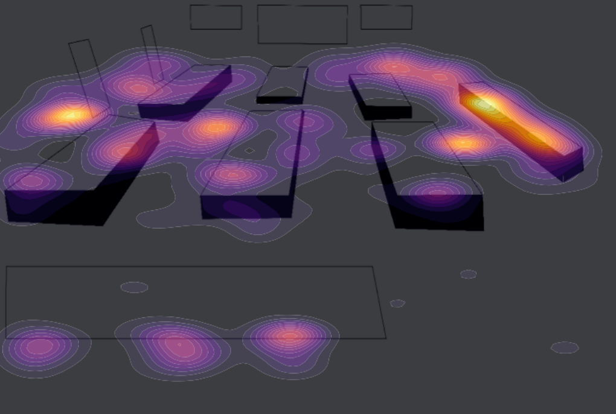

**Spatial density of tracked IDs, full drill.** 5 videos (4 × 50.2 min, 1 × 7.8 min)

99.8%

**Stable tracking**of detections kept on existing tracks; 0.05% IDs reassigned

0.32%

**Few long gaps**of detections separated by > 1 s

44.7%

**Moderate confidence**mean detection confidence ± 2.7%

27.2%

**Partial coverage per ID**of frames per ID; 5.3% of IDs on > 50% of frames

Movement captured without observers or wearables, input for layout and co-location

Results · Audio

## Audio results

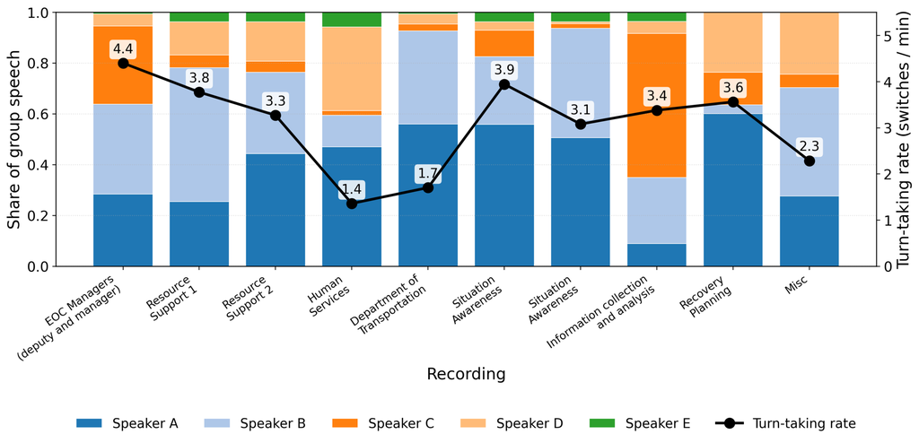

**Share of group speech and turn-taking rate, by recording.** 10 recordings, 272.9 ± 2.8 min each; 840 ± 268 utterances per recording

73.4%

**Speech-dense recordings**of recorded time contained speech

3.08/min

**Sequential turn-taking**15.8 s per turn; near-zero overlap

50.1%

**Uneven speaking shares**of group speech from the top speaker (range 35–60%)

0.87

**Highly connected speakers**mean degree centrality ± 0.21

Results · Audio

## Speaker connectivity over time

[video not shown]

Discussion

## Discussion

Prior workThis work

Self-report and observation miss proximity, movement, positioningDubrow & Bannan, 2019

→

Video tracking of movement and positioning, no observers

Wearable proximity sensors on every participantOzella et al., 2019

→

No added equipment or burden on responders during operations

Centralized communication as a source of leader overloadYuan & van Knippenberg, 2022

→

One speaker carries ~50% of speech; centrality as a real-time overload flag

Understanding EOC inner workings is time-intensiveMoon et al., 2018

→

Regions of interest point designers to congestion and coordination hotspots

Discussion

## Limitations

**Validation**

- No full manual validation yet; only part of processed video reviewed

**Video**

- ID switching persists across the EOC, worst for people far from the camera
- ID switching blocks individual-level behavioral analysis

**Audio**

- Coverage limited by recorder placement and number
- Diarization drift as speakers leave and join tables
- Pickup from neighboring tables; speaker ID inconsistencies, similar to video

Conclusions

## Unobtrusive multimodal measures surface sEOC human factors issues

**Cross-team situation awareness**

Low awareness of other teams (*M* = 2.41) despite highly connected speakers within teams (0.87)

**Movement as coordination**

Workers walk over to talk (*M* = 4.65); video captures movement without observers or wearables

**Concentrated communication load**

Top speaker carries 50% of group speech; centrality as a leader-overload signal

NEXT STEPS

→Support for cross-team information sharing

→Movement hotspots linked to layout redesign

→Real-time centrality to flag leader overload

→Video tracking validated against manual review

## References

Bewley et al., 2016. Bewley, A., Ge, Z., Ott, L., Ramos, F., & Upcroft, B. (2016). Simple online and realtime tracking. *2016 IEEE International Conference on Image Processing (ICIP)*, 3464–3468. https://doi.org/10.1109/ICIP.2016.7533003

Bredin et al., 2020. Bredin, H., Yin, R., Coria, J. M., Gelly, G., Korshunov, P., Lavechin, M., Fustes, D., Titeux, H., Bouaziz, W., & Gill, M.-P. (2020). Pyannote.Audio: Neural Building Blocks for Speaker Diarization. *ICASSP 2020*, 7124–7128. https://doi.org/10.1109/ICASSP40776.2020.9052974

Chai et al., 2019. Chai, A., Le, J. P., Lee, A. S., & Lo, S. M. (2019). Applying Graph Theory to Examine the Dynamics of Student Discussions in Small-Group Learning. *CBE—Life Sciences Education, 18*(2), ar29. https://doi.org/10.1187/cbe.18-11-0222

Cooke et al., 2000. Cooke, N. J., Salas, E., Cannon-Bowers, J. A., & Stout, R. J. (2000). Measuring Team Knowledge. *Human Factors, 42*(1), 151–173. https://doi.org/10.1518/001872000779656561

De Looze et al., 2015. De Looze, C., Vaughan, B., Kelly, F., & Kay, A. (2015). Providing Objective Metrics of Team Communication Skills via Interpersonal Coordination Mechanisms. *Conference Papers*. https://doi.org/10.21427/D7X208

Dubrow & Bannan, 2019. Dubrow, S., & Bannan, B. (2019). Toward Improving Situation Awareness and Team Coordination in Emergency Response with Sensor and Video Data Streams. In P. Zaphiris & A. Ioannou (Eds.), *HCII 2019, LNCS 11591*. Springer. https://doi.org/10.1007/978-3-030-21817-1_20

Kapucu, 2006. Kapucu, N. (2006). Interagency Communication Networks During Emergencies: Boundary Spanners in Multiagency Coordination. *The American Review of Public Administration, 36*(2), 207–225. https://doi.org/10.1177/0275074005280605

Kruyt et al., 2023. Kruyt, J., de Jong, D., D'Ausilio, A., & Beňuš, Š. (2023). Measuring Prosodic Entrainment in Conversation: A Review and Comparison of Different Methods. *Journal of Speech, Language, and Hearing Research, 66*(11), 4280–4314. https://doi.org/10.1044/2023_JSLHR-23-00094

Mathieu et al., 2000. Mathieu, J. E., Heffner, T. S., Goodwin, G. F., Salas, E., & Cannon-Bowers, J. A. (2000). The influence of shared mental models on team process and performance. *Journal of Applied Psychology, 85*(2), 273–283. https://doi.org/10.1037/0021-9010.85.2.273

Moon et al., 2018. Moon, J., Sasangohar, F., Peres, S. C., Neville, T. J., & Son, C. (2018). Modeling Team Cognition in Emergency Response via Naturalistic Observation of Team Interactions. *Proc. HFES Annual Meeting, 62*(1), 1801–1802. https://doi.org/10.1177/1541931218621408

Morian et al., 2023. Morian, H., Härgestam, M., Hultin, M., Jonsson, H., Jonsson, K., Nordahl Amorøe, T., & Creutzfeldt, J. (2023). Reliability and validity testing of team emergency assessment measure in a distributed team context. *Frontiers in Psychology, 14*. https://doi.org/10.3389/fpsyg.2023.1110306

Neal, 2003. Neal, D. M. (2003). Design characteristics of emergency operating centers: What we know and don't know. *Journal of Emergency Management, 1*(2), 35–38. https://doi.org/10.5055/jem.2003.0019

Ozella et al., 2019. Ozella, L., Gauvin, L., Carenzo, L., Quaggiotto, M., Ingrassia, P. L., Tizzoni, M., Panisson, A., Colombo, D., Sapienza, A., Kalimeri, K., Corte, F. D., & Cattuto, C. (2019). Wearable Proximity Sensors for Monitoring a Mass Casualty Incident Exercise: Feasibility Study. *JMIR, 21*(4), e12251. https://doi.org/10.2196/12251

Radford et al., 2022. Radford, A., Kim, J. W., Xu, T., Brockman, G., McLeavey, C., & Sutskever, I. (2022). Robust Speech Recognition via Large-Scale Weak Supervision. arXiv:2212.04356. https://doi.org/10.48550/arXiv.2212.04356

Schröter et al., 2022. Schröter, H., Escalante-B, A. N., Rosenkranz, T., & Maier, A. (2022). DeepFilterNet: A Low Complexity Speech Enhancement Framework for Full-Band Audio based on Deep Filtering. arXiv:2110.05588.

Taylor, 2011. Taylor, R. M. (2011). Situational Awareness Rating Technique (SART): The Development of a Tool for Aircrew Systems Design. In *Situational Awareness*. Routledge.

Wojke et al., 2017. Wojke, N., Bewley, A., & Paulus, D. (2017). Simple online and realtime tracking with a deep association metric. *2017 IEEE International Conference on Image Processing (ICIP)*, 3645–3649. https://doi.org/10.1109/ICIP.2017.8296962

Yuan & van Knippenberg, 2022. Yuan, Y., & van Knippenberg, D. (2022). Leader Network Centrality and Team Performance: Team Size as Moderator and Collaboration as Mediator. *Journal of Business and Psychology, 37*, 283–296. https://doi.org/10.1007/s10869-021-09745-4

Thank you!

Questions?

[figure not shown]

[figure not shown]

[figure not shown]

[figure not shown]

### Now

### Speaker notes

### Next

### Time budget per slide